# EXPLORATORY DATA ANALYSIS FOR WHITE WINES BY PAULA A. MUNOZ

> The goal of this project is to explore the White Wine Quality dataset and identify which chemical properties influence the quality of white wines.

# Exploring the data

> In this section, I will perform preliminary exploration of the white wine dataset.

```
##   fixed.acidity volatile.acidity citric.acid residual.sugar chlorides
## 1           7.0             0.27        0.36           20.7     0.045
## 2           6.3             0.30        0.34            1.6     0.049
## 3           8.1             0.28        0.40            6.9     0.050
## 4           7.2             0.23        0.32            8.5     0.058
## 5           7.2             0.23        0.32            8.5     0.058
## 6           8.1             0.28        0.40            6.9     0.050
##   free.sulfur.dioxide total.sulfur.dioxide density   pH sulphates alcohol
## 1                  45                  170  1.0010 3.00      0.45     8.8
## 2                  14                  132  0.9940 3.30      0.49     9.5
## 3                  30                   97  0.9951 3.26      0.44    10.1
## 4                  47                  186  0.9956 3.19      0.40     9.9
## 5                  47                  186  0.9956 3.19      0.40     9.9
## 6                  30                   97  0.9951 3.26      0.44    10.1
##   quality
## 1       6
## 2       6
## 3       6
## 4       6
## 5       6
## 6       6
```

```
## [1] 4898   12
```

```
##  fixed.acidity    volatile.acidity  citric.acid     residual.sugar
##  Min.   : 3.800   Min.   :0.0800   Min.   :0.0000   Min.   : 0.600
##  1st Qu.: 6.300   1st Qu.:0.2100   1st Qu.:0.2700   1st Qu.: 1.700
##  Median : 6.800   Median :0.2600   Median :0.3200   Median : 5.200
##  Mean   : 6.855   Mean   :0.2782   Mean   :0.3342   Mean   : 6.391
##  3rd Qu.: 7.300   3rd Qu.:0.3200   3rd Qu.:0.3900   3rd Qu.: 9.900
##  Max.   :14.200   Max.   :1.1000   Max.   :1.6600   Max.   :65.800
##    chlorides       free.sulfur.dioxide total.sulfur.dioxide
##  Min.   :0.00900   Min.   :  2.00      Min.   :  9.0
##  1st Qu.:0.03600   1st Qu.: 23.00      1st Qu.:108.0
##  Median :0.04300   Median : 34.00      Median :134.0
##  Mean   :0.04577   Mean   : 35.31      Mean   :138.4
##  3rd Qu.:0.05000   3rd Qu.: 46.00      3rd Qu.:167.0
##  Max.   :0.34600   Max.   :289.00      Max.   :440.0
##     density             pH          sulphates         alcohol
##  Min.   :0.9871   Min.   :2.720   Min.   :0.2200   Min.   : 8.00
##  1st Qu.:0.9917   1st Qu.:3.090   1st Qu.:0.4100   1st Qu.: 9.50
##  Median :0.9937   Median :3.180   Median :0.4700   Median :10.40
##  Mean   :0.9940   Mean   :3.188   Mean   :0.4898   Mean   :10.51
##  3rd Qu.:0.9961   3rd Qu.:3.280   3rd Qu.:0.5500   3rd Qu.:11.40
##  Max.   :1.0390   Max.   :3.820   Max.   :1.0800   Max.   :14.20
##     quality
##  Min.   :3.000
##  1st Qu.:5.000
##  Median :6.000
##  Mean   :5.878
##  3rd Qu.:6.000
##  Max.   :9.000
```

The structure of the data looks like this:

```
## 'data.frame':    4898 obs. of  12 variables:
##  $ fixed.acidity       : num  7 6.3 8.1 7.2 7.2 8.1 6.2 7 6.3 8.1 ...
##  $ volatile.acidity    : num  0.27 0.3 0.28 0.23 0.23 0.28 0.32 0.27 0.3 0.22 ...
##  $ citric.acid         : num  0.36 0.34 0.4 0.32 0.32 0.4 0.16 0.36 0.34 0.43 ...
##  $ residual.sugar      : num  20.7 1.6 6.9 8.5 8.5 6.9 7 20.7 1.6 1.5 ...
##  $ chlorides           : num  0.045 0.049 0.05 0.058 0.058 0.05 0.045 0.045 0.049 0.044 ...
##  $ free.sulfur.dioxide : num  45 14 30 47 47 30 30 45 14 28 ...
##  $ total.sulfur.dioxide: num  170 132 97 186 186 97 136 170 132 129 ...
##  $ density             : num  1.001 0.994 0.995 0.996 0.996 ...
##  $ pH                  : num  3 3.3 3.26 3.19 3.19 3.26 3.18 3 3.3 3.22 ...
##  $ sulphates           : num  0.45 0.49 0.44 0.4 0.4 0.44 0.47 0.45 0.49 0.45 ...
##  $ alcohol             : num  8.8 9.5 10.1 9.9 9.9 10.1 9.6 8.8 9.5 11 ...
##  $ quality             : int  6 6 6 6 6 6 6 6 6 6 ...
```

Confirming quality of the data, per results below the White Wine data set seems to be cleaned since there are no NAs

```
##        fixed.acidity     volatile.acidity          citric.acid
##                    0                    0                    0
##       residual.sugar            chlorides  free.sulfur.dioxide
##                    0                    0                    0
## total.sulfur.dioxide              density                   pH
##                    0                    0                    0
##            sulphates              alcohol              quality
##                    0                    0                    0
```

```
## [1]    0 4898
```

# Univariate Plots Section

> In this section I will create univariate plots to understand the structure of the individual variables in the White Wine dataset.

First, I’m going to take a look at the quality variable, since I’m looking to understand what makes a white wine a good wine

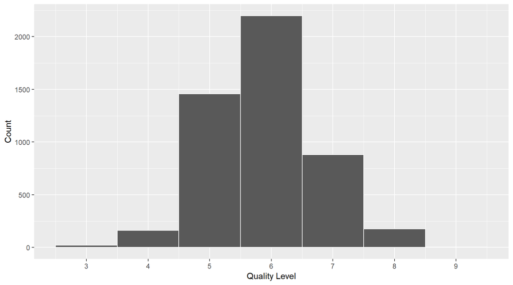

Actual counts by Quality:

```
##
##    3    4    5    6    7    8    9
##   20  163 1457 2198  880  175    5
```

Summary statistics of Quality:

```
##    Min. 1st Qu.  Median    Mean 3rd Qu.    Max.
##   3.000   5.000   6.000   5.878   6.000   9.000
```

We can conclude that Quality variable looks like it is normally distributed.

I’ll take a look at the Alcohol distribution

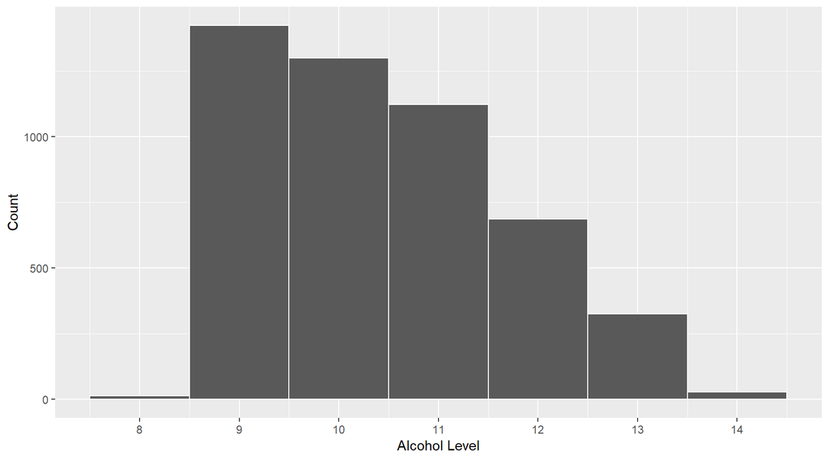

Summary statistics fro Alcohol:

```
##    Min. 1st Qu.  Median    Mean 3rd Qu.    Max.
##    8.00    9.50   10.40   10.51   11.40   14.20
```

Now, I will take a quick look at the distribution of all variables that contain numeric values in the white wine dataset:

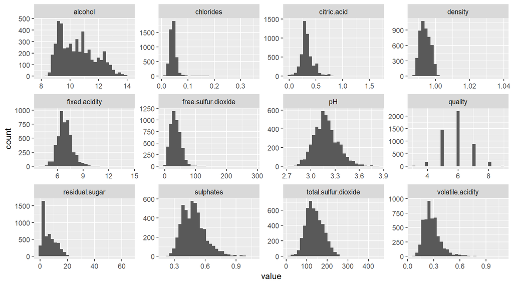

Looking at the distribution for all numeric variables, the variables that look more normally distributed are: pH and quality

Most of the variables show a Positive Skew distibution, specially: chlorides, density and residual.sugar

I’m going to transform the data for these variables showing a positive skew distribution to better understand these variables… The transformation that will be used is: log transformation

> Transforming Chlorides variable

Chlorides Histogram without transformation:

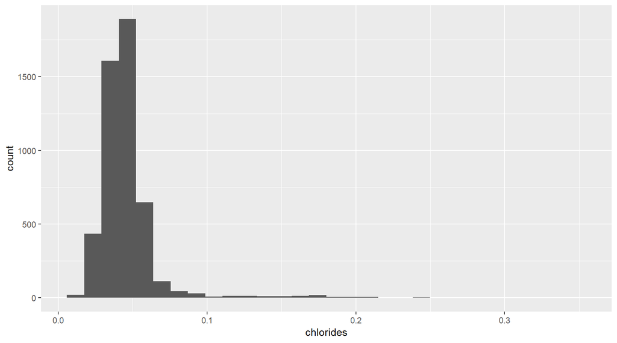

Chlorides Histogram with log transformation:

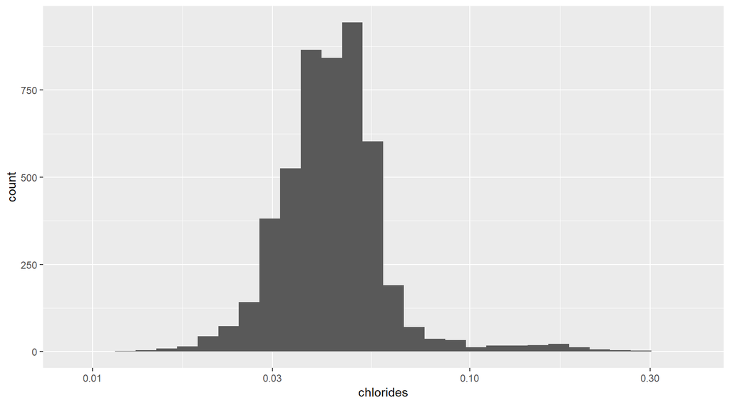

Now chlorides variable looks normally distributed with some outliers on the right.

> Transforming density variable

Density distribution without transformation:

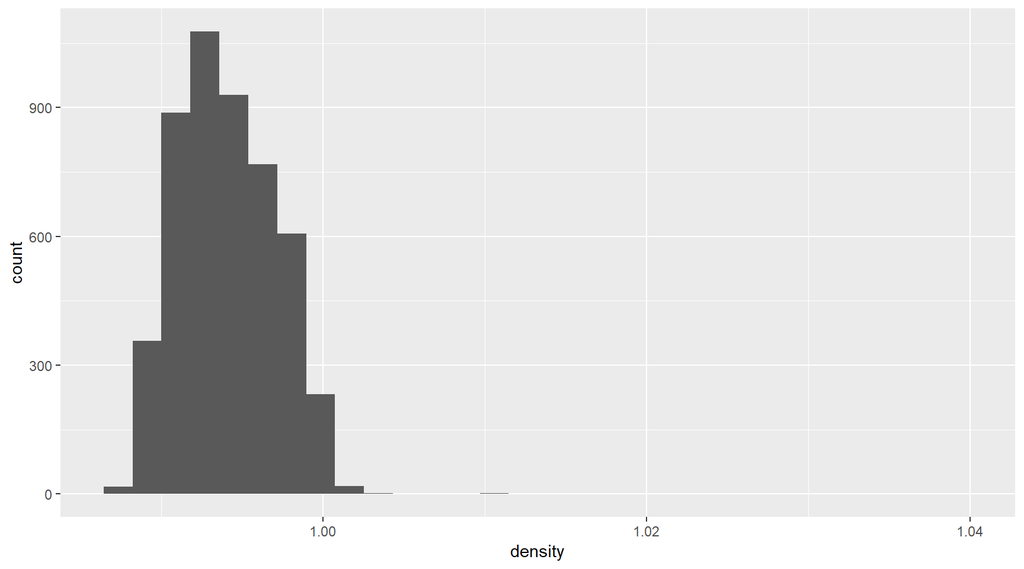

Density distribution with log transformation:

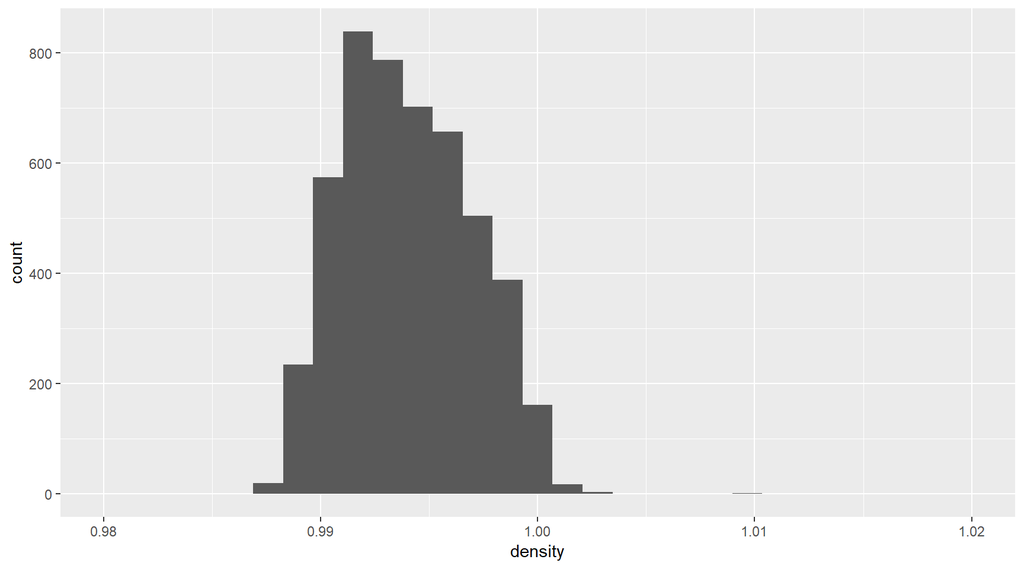

```
##    Min. 1st Qu.  Median    Mean 3rd Qu.    Max.
##  0.9871  0.9917  0.9937  0.9940  0.9961  1.0390
```

When looking at the transformation for density we can clearly see that most values are between 0.99 and 1.00 g/ cm3, but there are some outliers on 1.01 and 1.04 g / cm3 that makes the distribution so positively skewed.

> Transforming residual.sugar variable

residual.sugar distribution without transformation

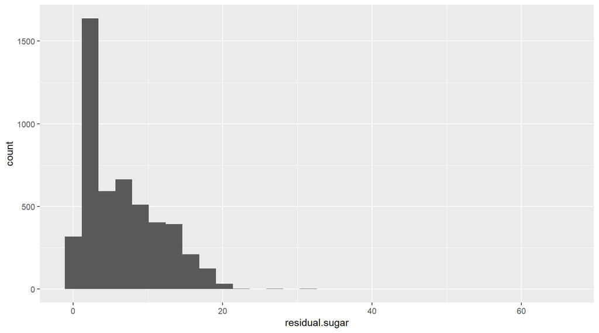

residual.distribution with log transformation:

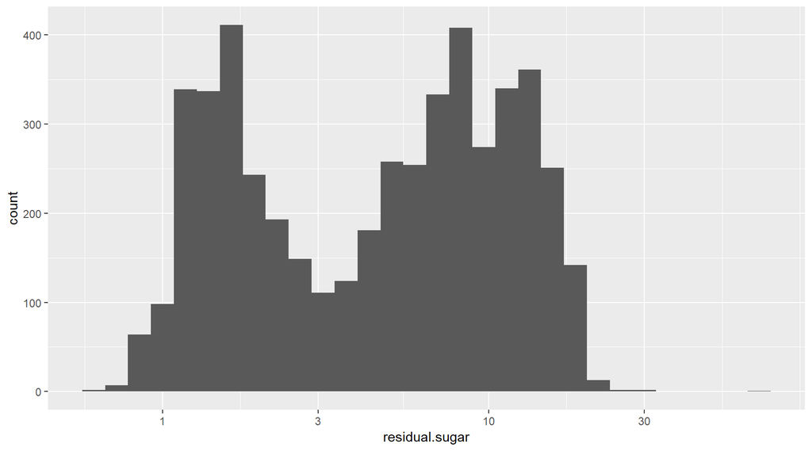

```
##    Min. 1st Qu.  Median    Mean 3rd Qu.    Max.
##   0.600   1.700   5.200   6.391   9.900  65.800
```

After transforning the residual.sugar variable, the distribution seems to be a bimodal distribution

# Univariate Analysis

### What is/are the main feature(s) of interest in your dataset?

The main feature of interest is Quality, since the objective of the project is to understand what are the features that influence the queality of the wine.

### What other features in the dataset do you think will help support your analysis?

I’m still on early stages of the analysis where only unvariate analysis have been done, thus predicting which other variables will be helpful is a difficult task, I expect to have a better idea after bivariate and multivariate analysis have been done.

### Did you create any new variables from existing variables in the dataset?

I have not created any variable yet

### Of the features you investigated, were there any unusual distributions?

# Bivariate Plots Section

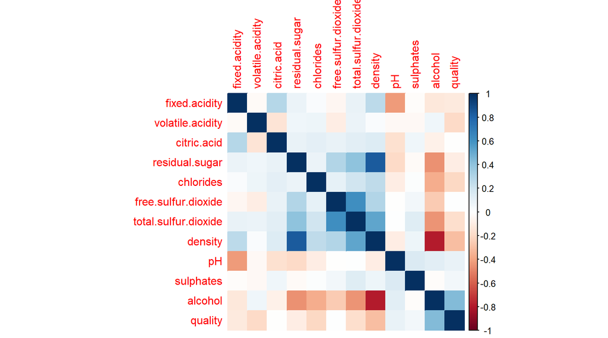

Correlogram with correlation coefficient number:

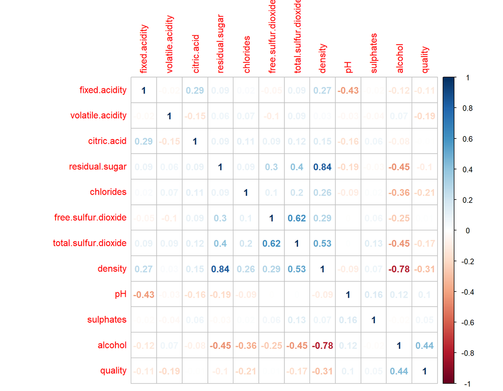

From Matrix above, we can identify that there is really strong correlation between the following variables:

- Alcohol and density (Negative correlation: -0.78)
- density and residual.sugar (Positive correlation: 0.84)

There is some but not as strong correlation between the following variables:

- total.sulfur.dioxide and free.sulfur.dioxide (Positive correlation: 0.62)
- density and total.sulfur.dioxide (Positive correlation:0.53)
- Alcohol and residual.sugar (Negative correlation: -0.45)
- Alcohol and total.sulfur.dioxide (Negative correlation: -0.45)
- Quality and alcohol (Positive correlation: 0.44)
- pH and fixed.acidity (Negative correlation: -0.43)
- Alcohol and chlorides (Negative correlation: -0.36)
- Quality and density (Negative correlation: -0.31)

# Analyzing the Strong correlations per Correlogram:

- Alcohol and density (Negative correlation: -0.78)

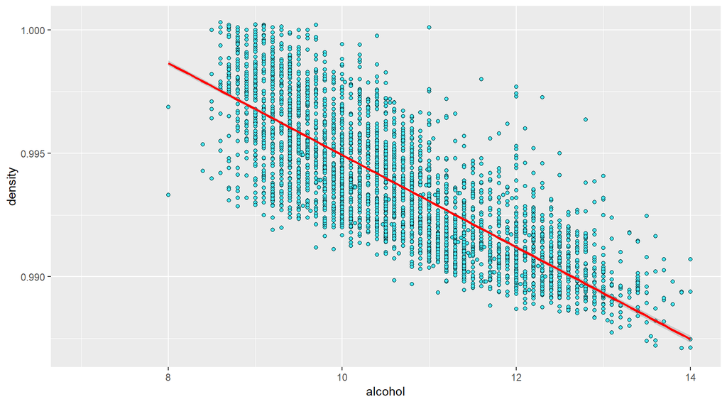

What’s the correlation betwen the two variables alcohol and density?

```
##
##  Pearson's product-moment correlation
##
## data:  alcohol and density
## t = -87.255, df = 4896, p-value < 2.2e-16
## alternative hypothesis: true correlation is not equal to 0
## 95 percent confidence interval:
##  -0.7908646 -0.7689315
## sample estimates:
##        cor
## -0.7801376
```

- density and residual.sugar (Positive correlation: 0.84)

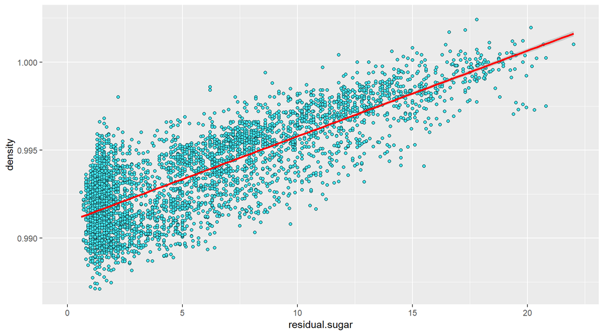

What’s the correlation betwen the two variables residual.sugar and density?

```
##
##  Pearson's product-moment correlation
##
## data:  residual.sugar and density
## t = 107.87, df = 4896, p-value < 2.2e-16
## alternative hypothesis: true correlation is not equal to 0
## 95 percent confidence interval:
##  0.8304732 0.8470698
## sample estimates:
##       cor
## 0.8389665
```

# Exploring more in depth the feature of Interest Quality:

what is the alcohol level per Quality Level?

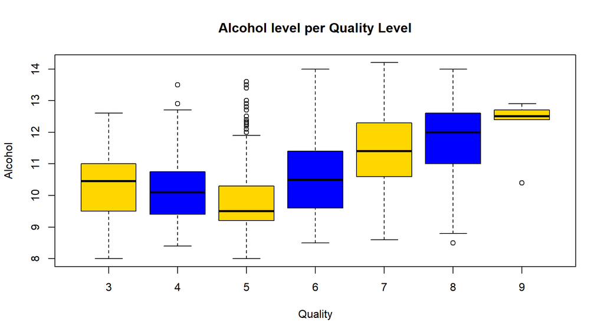

From boxplot above, we can see that Quality Level 9 has a high level of alcohol, which is not very dispersed.

what is the density per Quality Level?

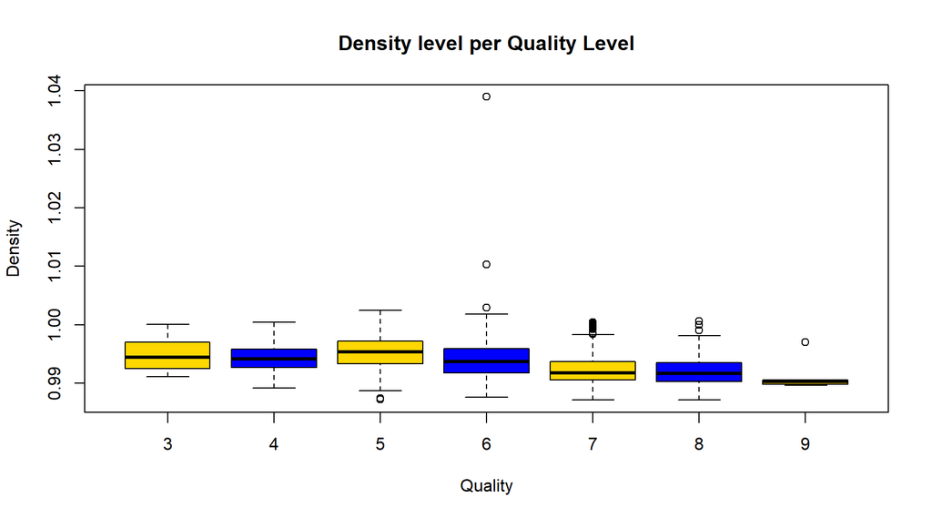

From boxplot above, we can see that Quality Level 9 has a very low density.

what is the Residual Sugar per Quality Level?

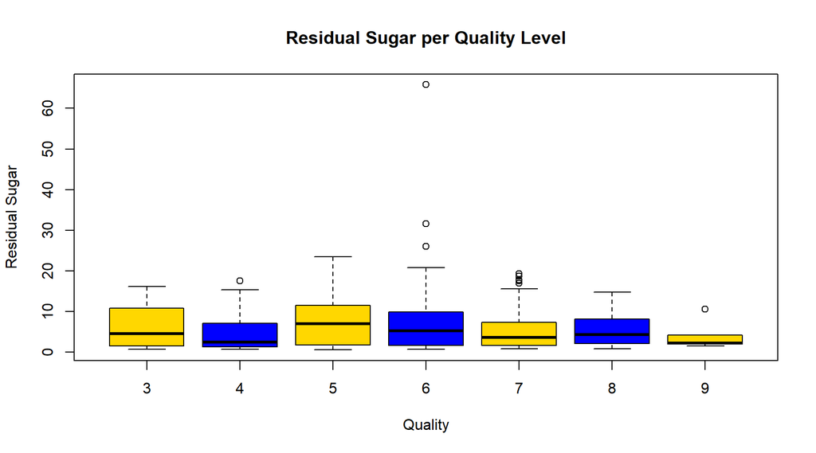

From boxplot above, we can see that Quality Level 9 has very low residual sugar.

what is the pH per Quality Level?

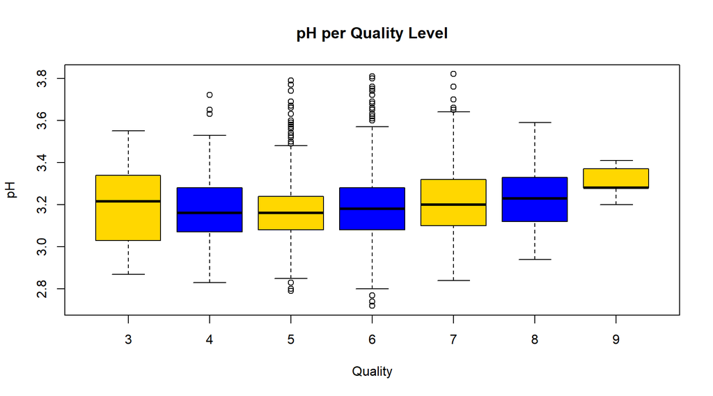

what is the Fixed Acidity per Quality Level?

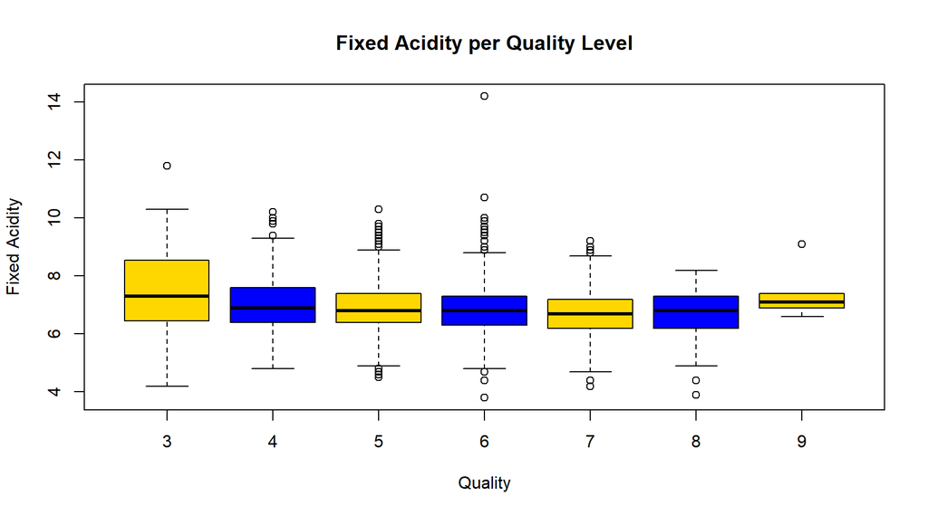

what is the Total sulfur Dioxide per Quality Level?

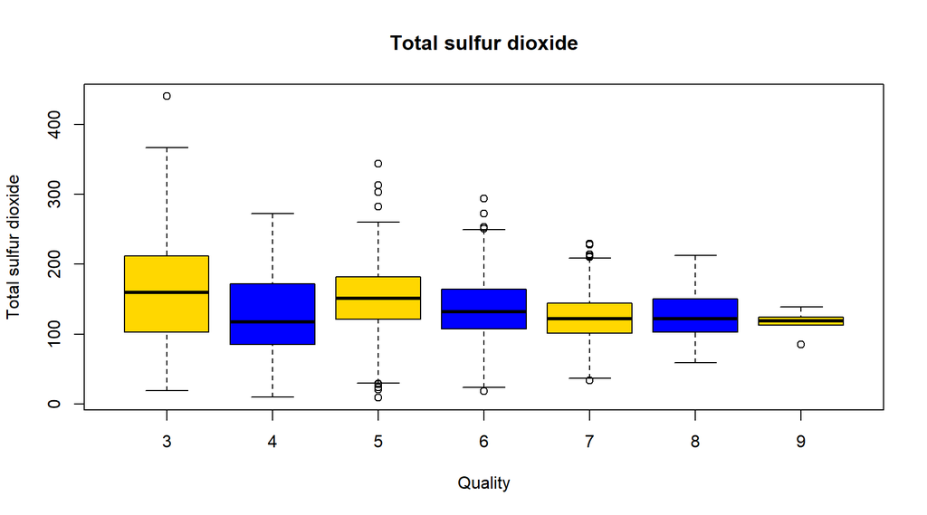

## Bivariate Analysis

I was able to identify that there is really strong correlation between the following variables:

- Alcohol and density (Negative correlation: -0.78)
- density and residual.sugar (Positive correlation: 0.84)

There is some but not as strong correlation between the following variables:

- total.sulfur.dioxide and free.sulfur.dioxide (Positive correlation: 0.62)
- density and total.sulfur.dioxide (Positive correlation:0.53)

When analyzing the feature of interest (quality) with other variables such as alcohol, density, residual.sugar it was intersting to see that for quality level nine, there was not much dispersion between data points, and there were almost no outliers.

In overall white wines with quality level nine seem to have a high concentration of alcohol,

# Multivariate Plots Section

# Analyzing the Strong correlations and Quality

- Alcohol and density (Negative correlation: -0.78)

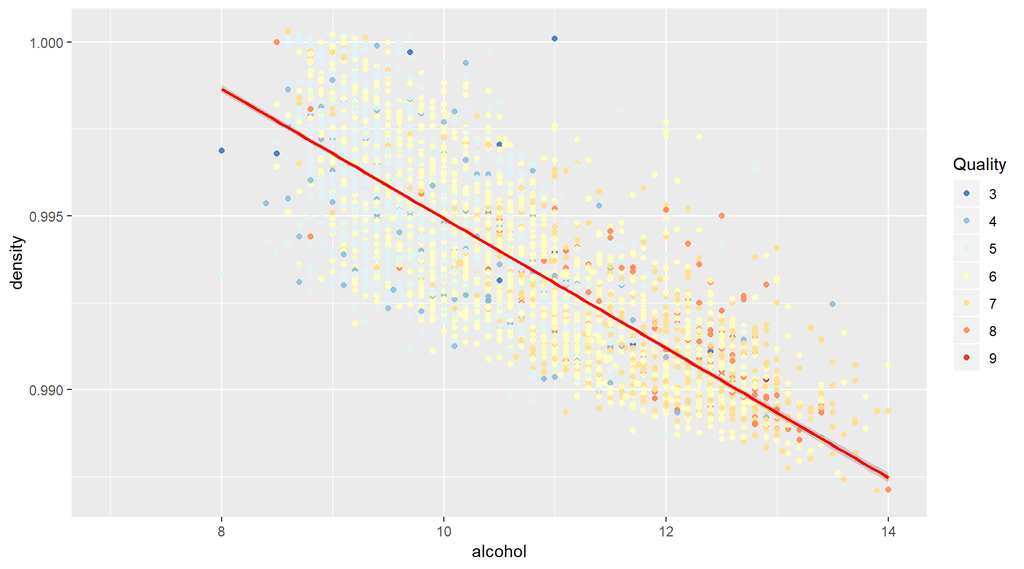

- density and residual.sugar (Positive correlation: 0.84)

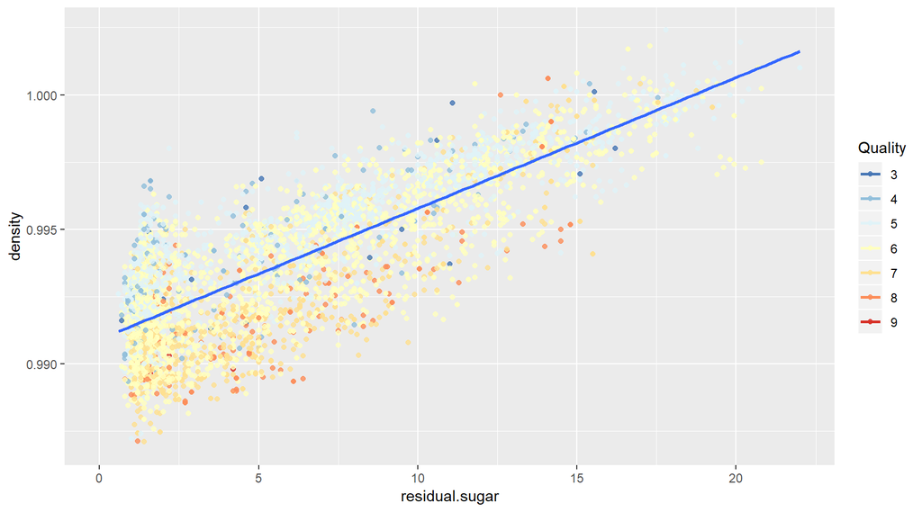

- density and total.sulfur.dioxide (Positive correlation:0.53)

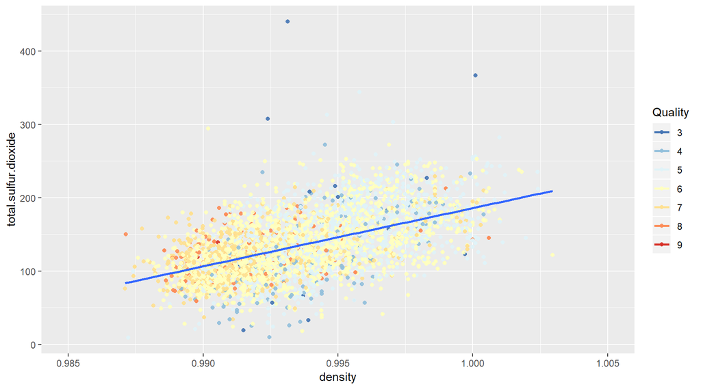

# Multivariate Analysis

I was able to confirm the statements mentioned during the biviriate analysis such a:

White wines with quality level nine seem to have a high concentration of alcohol, with low density… This is based on new scatter plots visualizations where I used quality as the third dimension, and I can see how quality nine (red color) is more concentrated in particular areas based on the other two variables.

For example when comparing density vs alcohol, I can see a high concentration of red point on lower right corner wich indicates low density and high alcohol values.

# Final Plots and Summary

### Plot One

what is the alcohol level per Quality Level?

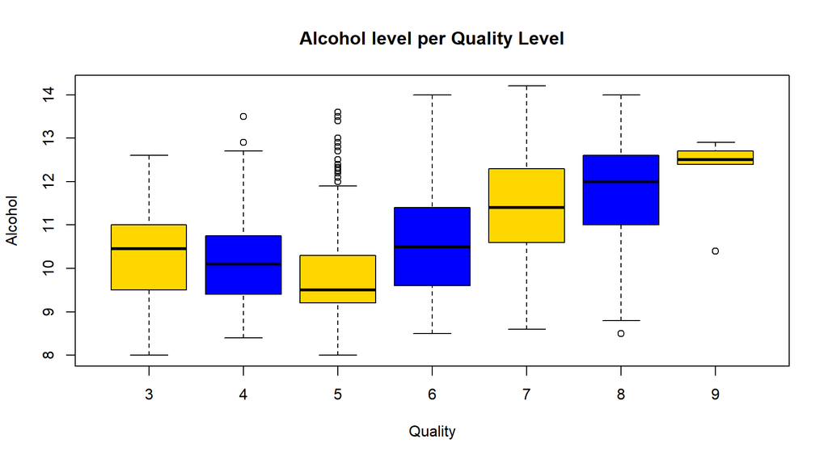

### Description One

From boxplot above, we can see that Quality Level 9 has a high level of alcohol, which is not very dispersed.

### Plot Two

- Alcohol and density (Negative correlation: -0.78)

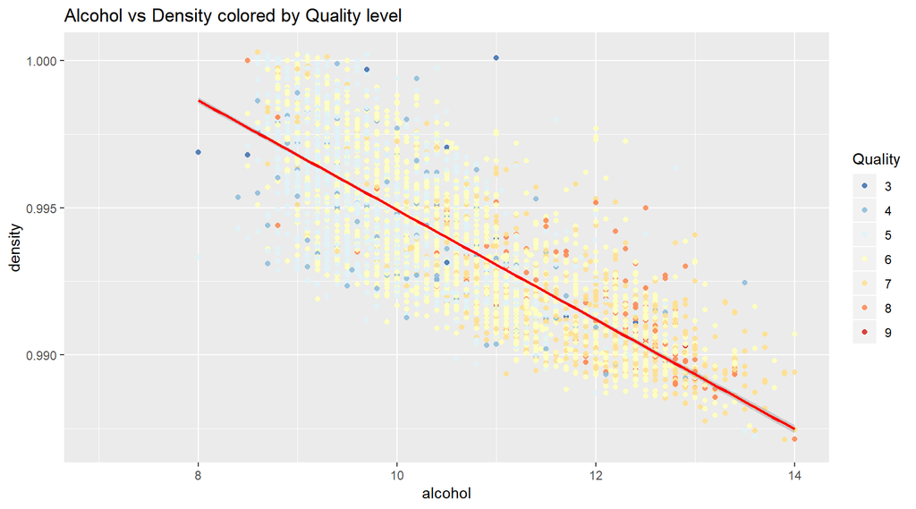

### Description Two

White wines with quality level nine seem to have a high concentration of alcohol, with low density.

### Plot Three

- density and residual.sugar (Positive correlation: 0.84)

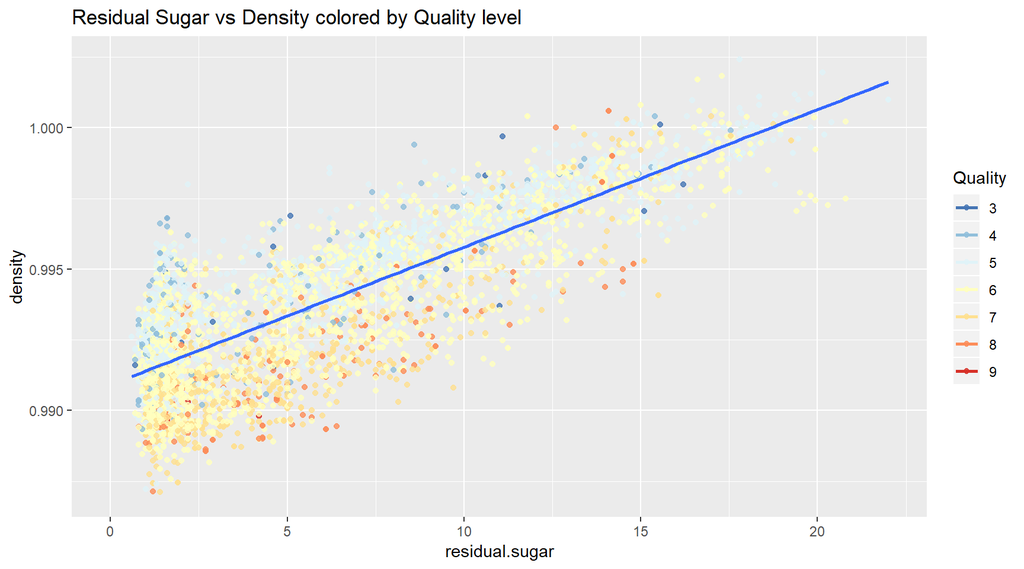

### Description Three

As residual sugar increases the density increases as well, however I see a high concentration of red data points (Higher quality) on the lower left corner which infers that high quality wines have a low residual sugar level as well as low density.

# Reflection

This project was a nice introduction to Exploratory Data analysis, where we start by evaluating the structure of the data, and getting familiar with the different variables in our data set, then we start making some progress in our analysis by doing univariate, bivariate and multivariate analysis to find meaningful and interesting relationships between the variables.

I believe that if I would have had more knowledge about the topic (White wines), I would have been able to find and demonstrate more interesting facts.

I found this project to be a little bit challenging, specially since I’ve never used the R Markdown and was having issues trying to knit the project so it would look properly.

This Project could be expanded in the future by trying to implement a model and see how well it fits the data.

# References:

- R-studio website
- R graphics with ggplot workshop notes: https://tutorials.iq.harvard.edu/R/Rgraphics/Rgraphics.html